# Water boiling point according to daily pressure

2023-09-25

## Defining boiling point

The boiling point of a substance is the temperature at which the vapor pressure of that substance is equal to atmospheric pressure. This relationship can be described with the Clausius-Clapeyron Equation.

$ln(\frac{P_1}{P_2}) = \frac{\Delta H_{vap}}{R}(\frac{1}{T_2}-\frac{1}{T_1})$

The enthalpy of vaporization of water $\Delta H_{vap} = 40.7 \frac{kJ}{mol}$ and the gas constant $R = 8.3145 \frac{J}{mol K}$

The vapor pressure of water is 1.0 atm at 373 K. We can use this known relationship to calculate the daily boiling point of water with the Clausius-Clapeyron Equation. NCAR records atmospheric pressure at the Foothills Laboratory in Boulder, Colorado in units of hectopascals 1.0 atm = 1,013.25 hPa.

## Extracting pressure data

2023 Weather data were extracted for this analysis from the foothills laboratory (ftp://ftp.eol.ucar.edu/pub/archive/weather/foothills). Data were processed for atmospheric pressure, recorded every five minutes.

[figure not shown]

```r
file_names <- list.files(path = "weather_data/")
pressure_data <- lapply(paste0("weather_data/", file_names), function(i){
  date <- unlist(str_split(i, "\\."))[2]
  nc_data <- nc_open(i)
  t <- ncvar_get(nc_data, "time")
  pressure <- ncvar_get(nc_data,"pres")
  tibble(date = as_date(date),
         time_sec = t,
         pressure_hPa = pressure)}) %>%
  reduce(full_join, by = c("date","time_sec","pressure_hPa")) %>%
  mutate(date = date + seconds(time_sec)) %>%
  select(-time_sec)

ggplot(data=pressure_data,aes(x=date,y=pressure_hPa)) +
  geom_line() + theme_classic() + labs(y = 'Boiling Point (°F)', x = 'Date')
```

## Calculating boiling point according to atmospheric pressure

By applying this equation to the NCAR dataset, we can determine the variation in the boiling point of water across 2023 (up to September).

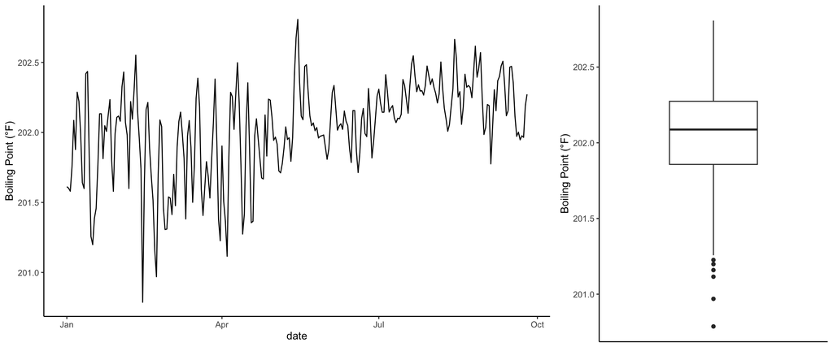

```r
clausius_func_water <- function(pressure){
  R <- 8.3145/1000
  delta_H <- 40.7
  1/((R/delta_H)*log(1013.25/pressure) + (1/373))
}

pressure_data <- pressure_data %>%
  mutate(date = date(date)) %>%
  group_by(date) %>%
  summarise(pressure_hPa = mean(pressure_hPa)) %>%
  mutate(boiling_point_K = clausius_func_water(pressure_hPa)) %>%
  mutate(boiling_point_F = (boiling_point_K - 273.15) * 1.8 + 32)


line_plot <- ggplot(data=pressure_data,aes(x=date,y=boiling_point_F)) +
  geom_line() + theme_classic() + ylab('Boiling Point (°F)')
boxplot <- ggplot(data=pressure_data,aes(y=boiling_point_F)) +
  geom_boxplot() + scale_x_discrete() + theme_classic() +
  ylab('Boiling Point (°F)')
plot_grid(line_plot,boxplot, rel_widths=c(2,1))
```

```r
mean <- mean(pressure_data$boiling_point_F)
range <- max(pressure_data$boiling_point_F) - min(pressure_data$boiling_point_F)
```

The average calculated boiling point across this time range is 202.03 °F, while the difference in minimum and maximum values is 2.02 °F